# Topic models

Andrew P Blake

October 2020

> *Disclaimer: The Bank of England does not accept any liability for misleading or inaccurate information or omissions in the information provided. The subject matter reflects the views of the individual presenter and not the wider Bank of England or its Policy Committees.*

## Topics from text

**Topic modelling** was introduced to text analysis by Blei, Ng, and Jordan (2003), who had the idea that topics in text could be characterized by a propensity to use words in particular combinations, and those combinations could be described by a suitable distribution. This has been generalized in many dimensions since (e.g. Blei and Lafferty (2007) or Roberts, Stewart, and Airoldic (2016)), and implementations in R include Grün and Hornik (2011), Chang (2015) and Roberts, Stewart, and Tingley (2019).

I’ll focus on the original proposal. What Blei, Ng, and Jordan (2003) suggested was that the text could be modeled using the **Dirichlet distribution**. Thus each **topic** is a [Dirichlet distribution](https://en.wikipedia.org/wiki/Dirichlet_distribution) of words, and topics are allocated to each **document** in proportions, with each document the sum of available topics. So a document could be almost all one topic, or a mixture of two or more. Estimation these unknown densities that represent the topics and then assigning them to documents is a process known as [*Latent Dirichlet Allocation*](https://en.wikipedia.org/wiki/Latent_Dirichlet_allocation) (LDA). Essentially is is a multivariate distribution of the proportions of each words defining each topic, with each document made up of the topics with weights specific to the document given the topic.

What this requires us to buy as a way of modelling the topics is that there are a number of documents which are made up of a given number of topics in different proportions. This is quite a strong assumption, but seems to work. Approaching this is remarkably easy. The example used here is the Bank of Canada’s *Monetary Policy Report*, which have been published at least twice a year since 1995. The documents need to be tokenized by single words[^1], then stop words removed, possibly some other irrelevant words[^2], a *document term matrix* created and then factorized. I can then produce some great graphs of the topic contents and the discussion timeline.

## Read the text

Load some libraries.

```r
library(pdftools)     # Read pdfs
library(stringi)

library(tidyverse)
library(lubridate)
library(tidytext)     # Tidy text!
library(ggwordcloud)  # Wordclouds in ggplot2
library(SnowballC)    # Word stemmer

library(topicmodels)  # Package for LDA

library(cowplot)      # plot_grid below from this
library(RColorBrewer) # So we can get consistent colors
```

This function is specifically tailored to read a Canadian *Monetary Policy Report* to a data frame.

```r
text_to_frame = function(pdf_file) {

  date  <- as.Date(substr(pdf_file,5,14))
  mths  <- month.abb[month(date)]
  yrs   <- year(date)

  MPR <- suppressMessages(pdf_text(pdf_file))
  MPR <- gsub("\r\n"," ",MPR)
  MPR <- gsub("\t"," ",MPR)
  # MPR <- stringi::stri_escape_unicode(MPR)
  MPR <- stri_trans_general(MPR, "latin-ascii")
  MPR <- iconv(MPR, "UTF-8", "ASCII", sub = " ")
  MPR <- gsub("[[:digit:]]+"," ",MPR)
  # MPR <- gsub("[[:punct:]]+"," ",MPR)
  MPR <- gsub("[[:space:]]+"," ",MPR)
  MPR <- tolower(trimws(MPR))
  MPR <- gsub("monetary policy report"," ",MPR)
  MPR <- gsub("onetary policy report"," ",MPR)
  MPR <- gsub("netary policy report"," ",MPR)
  MPR <- gsub("m o n e t a r y p o l i c y r e p o r t","",MPR)
  MPR <- gsub("r e p o r t o n m o n e t a r y p o l i c y","",MPR)
  MPR <- gsub("bank of canada"," ",MPR)
  MPR <- gsub("b a n k o f c a n a d a","",MPR)
  MPR <- gsub("[[:space:]]+"," ",MPR)
  MPR <- gsub("file information for internal use only"," ",MPR)

  MPR <- trimws(MPR)
  MPR_add <- tibble(page=1:length(MPR),
                    document=pdf_file,
                    year=year(date),
                    month=mths,
                    text=MPR)

  gg <- MPR_add$text
  lm <- tolower(month.name[month(date)])
  cm <- paste0("^", lm)
  for (l in 1:2) {
    gg <- trimws(gsub("^global economy", "", gg))
    gg <- trimws(gsub("^canadian economy", "", gg))
    gg <- trimws(gsub("^appendix", "", gg))
    gg <- trimws(gsub("^update", "", gg))
    gg <- trimws(gsub("^risks to the inflation outlook", "", gg))
    gg <- trimws(gsub("^reassessment of canadian potential output growth", "", gg))
    gg <- trimws(gsub(cm, "", gg))
    gg <- trimws(gsub(trimws(gsub("", " ", lm)), "", gg))
    gg <- trimws(gsub("^chart", "", gg))
    gg <- trimws(gsub("^box", "", gg))
    gg <- trimws(gsub("^table", "", gg))
  }
  gg <- trimws(gsub("bankofcanada ca", "", gg))
  wr <- which(word(gg) == "bibliography")
  if (length(wr) < 1) wr <- which(word(gg) == "references")

  MPR_add$text <- gg

  if (length(wr) > 0) MPR_add <- MPR_add[1:(wr-1),]

  MPR_add <- MPR_add %>%
    filter(word(text, 1) != "") %>%
    filter(word(text, 1) != "contents") %>%
    filter(word(text, 5, 6) != "sixtieth anniversary") %>%
    filter(word(text, 1, 3) != "the silver dollar") %>%
    filter(word(text, 2, 3) != "sterling silver") %>%
    filter(word(text, 2, 3) != "gold coin") %>%
    filter(word(text, 1, 2) != "gold coin") %>%
    filter(word(text, 1, 3) != "library of parliament") %>%
    filter(word(text, 1, 4) != "this is a report") %>%
    filter(word(text, 1, 5) != "this text is a commentary") %>%
    filter(word(text, 1, 5) != "canada s inflation control strategy")

  return(MPR_add)
}
```

It turns out there are a lot of words I might want to exclude, many of which are rather spuriously introduced in some of the graphs. A casual pre-inspection of some of the words indicates that the following are not really part of the documents. I also exclude the months.

```r
suppress <- tibble(word=c("chart", "axis", "proj'd" , "line", "space", "marks",
                          "styles", "axes", "edge", "left", "scale", "dot",
                          "lines", "stacking", "ticks", "centered", "en.indd",
                          "minor", "page", "white", "width", "alignment", "artwork",
                          "tick", "title", "bottom", "st", "labels", "observations",
                          "source",  tolower(month.name)))

files <- list.files(pattern = "^mpr.+pdf$")

mpr_terms <- list()
for(j in 1:length(files)) {

  MPR <- text_to_frame(files[[j]]) # %>%
  # mmutate(text = gsub("[[:punct:]]+", " ", text))

  # Unnest tokens to single words
  tidy_MPR <- MPR %>%
    unnest_tokens(word, text) %>%
    anti_join(stop_words, by="word") %>%
    anti_join(suppress, by="word")

  mpr_terms[[j]] <- tidy_MPR %>%
    group_by(word) %>%
    summarise(n=n(), .groups="drop") %>%
    arrange(desc(n)) %>%
    mutate(Doc = files[j])

}
```

### Should we exclude the updates?

Is it the case that the off-round update documents are different in some way? If so should we exclude them? It is easiest to see if they are different in length using a column plot. I’ve done a little pre-analysis, and I think the updates all have less than 2850 words. Let’s see. I create an indicator variable called `Update`, which I set to `red` or `blue`.

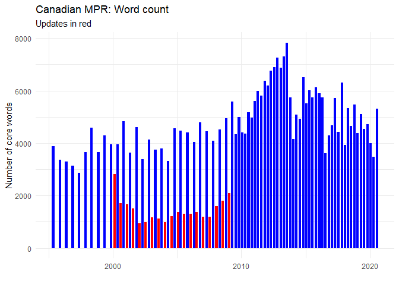

```r
mpr_terms <- bind_rows(mpr_terms) %>%
  mutate(word = wordStem(word)) %>%
  group_by(Doc) %>%
  mutate(T = sum(n)) %>%
  ungroup() %>%
  mutate(Date = as.Date(str_sub(Doc, 5))) %>%
  mutate(Update = if_else(T < 2850, "red", "blue"))

wplot <- mpr_terms %>%
  select(Date,T, Update) %>%
  distinct() %>%
  ggplot() +
  geom_col(aes(x=Date, y=T, fill=Update)) +
  scale_fill_identity() +
  theme_minimal() +
  theme(legend.position = "none") +
  labs(title="Canadian MPR: Word count",
       subtitle="Updates in red",
       x="", y="Number of core words")

plot(wplot)
```

They are shorter, but clearly the first update is quite long – almost as long as some main reports. But it is also clear that the reports that replaced them were not shorter: the four-times-a-year version was as long or longer than the bi-annual ones. I will drop all the updates as they seem predominantly significantly shorter.

A quick side question. Is the pattern down to the person at the top? Binette and Tchebotarev (2019) seem to think it might be… Let’s add a little indicator of the tenure of each Governor.[^3]

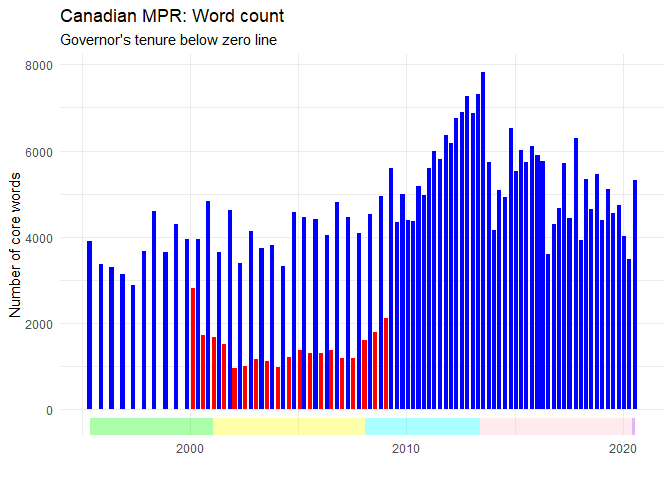

```r
# Dates for governors
rect_df <-
  tibble(wh = c("Macklem","Poloz","Carney","Dodge","Theissen"),
         st = as.Date(c("2020-06-01", "2013-06-01", "2008-02-01", "2001-02-01", "1994-02-01"))) %>%
  mutate(xl=st, xl=if_else(xl<min(mpr_terms$Date), min(mpr_terms$Date), st)) %>%
  mutate(xh=lag(st), xh=if_else(is.na(xh), max(mpr_terms$Date), xh)) %>%
  mutate(yl=-Inf, yh=-200, cc=c("purple", "pink", "cyan", "yellow", "green"))

wplot + geom_rect(data=rect_df, aes(xmin=xl, xmax=xh, ymin=yl, ymax=yh, fill=cc), alpha=0.33) +
  labs(subtitle="Governor's tenure below zero line")
```

It is beginning to look like Governor number 3 (Mark Carney) is a bit different.

### DTM

I need to create a *document term matrix*. This is at it’s most basic a matrix of word counts, with a single row per document, and a single column for each term. `tidytext` has several functions to create these, and we use `cast_dtm`, having dropped the update documents.[^4]

```r
# DTM
dtm_mpr <- mpr_terms %>%
  filter(Update=="blue") %>%
  cast_dtm(Doc,word,n)

print(dtm_mpr)
```

```
## <<DocumentTermMatrix (documents: 74, terms: 5980)>>
## Non-/sparse entries: 72295/370225
## Sparsity           : 84%
## Maximal term length: 26
## Weighting          : term frequency (tf)
```

As can be seen from the output, there are almost 6000 terms over the 74 documents.

Although the object returned from this has a lot of information it it, the most important part is the actual document term matrix itself, giving counts of each term for each document, so the first few lines of it in long `tidy` format are:

```r
tidy(dtm_mpr)
```

```
## # A tibble: 72,295 x 3
##    document           term   count
##    <chr>              <chr>  <dbl>
##  1 mpr-1995-05-15.pdf inflat   147
##  2 mpr-1995-11-20.pdf inflat    76
##  3 mpr-1996-05-20.pdf inflat   119
##  4 mpr-1996-11-20.pdf inflat    84
##  5 mpr-1997-05-20.pdf inflat    87
##  6 mpr-1997-11-20.pdf inflat   135
##  7 mpr-1998-05-13.pdf inflat   106
##  8 mpr-1998-11-16.pdf inflat    69
##  9 mpr-1999-05-19.pdf inflat    87
## 10 mpr-1999-11-17.pdf inflat   109
## # ... with 72,285 more rows
```

More usefully, the first eight rows and columns in wide format are easily obtained as:

```r
tidy(dtm_mpr) %>%
  pivot_wider(names_from=term, values_from=count, names_repair = "unique") %>%
  slice(1:8) %>%
  select(1:9) %>%
  knitr::kable() %>%
  kableExtra::kable_styling()
```

| document…1 | inflat | rate | price | cent | monetari | cpi | polici | exchang |
| --- | --- | --- | --- | --- | --- | --- | --- | --- |
| mpr-1995-05-15.pdf | 147 | 64 | 63 | 51 | 49 | 41 | 39 | 32 |
| mpr-1995-11-20.pdf | 76 | 63 | 36 | 32 | 36 | 24 | 14 | 21 |
| mpr-1996-05-20.pdf | 119 | 71 | 30 | 41 | 33 | 19 | 16 | 14 |
| mpr-1996-11-20.pdf | 84 | 52 | 30 | 39 | 36 | 20 | 6 | 19 |
| mpr-1997-05-20.pdf | 87 | 45 | 24 | 43 | 24 | 26 | 4 | 8 |
| mpr-1997-11-20.pdf | 135 | 42 | 24 | 47 | 41 | 36 | 15 | 8 |
| mpr-1998-05-13.pdf | 106 | 40 | 43 | 69 | 45 | 32 | 22 | 7 |
| mpr-1998-11-16.pdf | 69 | 50 | 34 | 50 | 19 | 30 | 10 | 12 |

The stemmed version of inflation, *inflat*, is clearly widely in each document, but we don’t know in what context it is being used.

## LDA

Now the LDA is performed. The number of topics needs to be chosen as an input to the algorithm. I pick nine, which is not really enough but will run relatively quickly. Also it works quite well for this data in terms of the story.

```r
# LDA
k       <- 9
control <- list(seed=12344321, verbose=2000, iter=1000, burnin=1000)
lda_mpr <- LDA(dtm_mpr, k=k, method="Gibbs", control=control)
```

```
## K = 9; V = 5980; M = 74
## Sampling 2000 iterations!
## Iteration 2000 ...
## Gibbs sampling completed!
```

We can retrieve both the words that form the topics and their distribution per topic (beta), and the distribution of those topics over the documents (gamma). There are `tidy` methods built into `tidytext` which will extract these elements easily.

```r
lda_word_mpr <- tidy(lda_mpr, matrix="beta")
lda_doc_mpr  <- tidy(lda_mpr, matrix="gamma") %>%
  mutate(date = as.Date(str_sub(document,5)))
```

Note the documents are best indexed by the date they were written. We can then plot the results in a variety of ways. First, it is common to display words in *Word Clouds*. I pick the 22 most important words in terms of how much of the distribution they explain, and use `geom_text_wordcloud`, weighting the size of each word by `beta`.

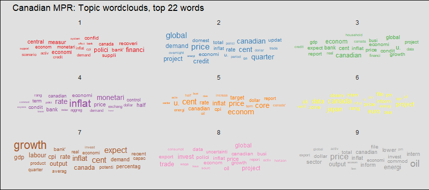

```r
getPalette <- colorRampPalette(brewer.pal(9, "Set1"))   # Specify a function to generate colours for topics

pword_clouds <- lda_word_mpr %>%
  group_by(topic) %>%
  top_n(22, beta) %>%
  ungroup() %>%
  ggplot() +
  geom_text_wordcloud(aes(label=term, size=beta, colour=as.factor(topic))) +
  scale_colour_manual(values=getPalette(k)) +
  facet_wrap(~ topic) +
  theme_minimal() +
  theme(legend.position="none", plot.background=element_rect(fill="grey88")) +
  labs(title="Canadian MPR: Topic wordclouds, top 22 words", x="", y="")

plot(pword_clouds)
```

These are quite nice, but bar charts are sometimes more informative particularly with respect to proportions. There is also information about `gamma`, the proportions of the topics that make up the documents. In this context, as each MPR is dated there is a timeline for the topics that can be matched to events, as is done in Binette and Tchebotarev (2019).

The next bit of code appends the topic colors to the document information.

```r
lda_doc_mpr <- lda_doc_mpr %>%
  left_join(tibble(topic=1:k, cc=getPalette(k)), by="topic")
```

Now create bar charts for the topics and timelines in two different graphs for the topic proportions in the documents.

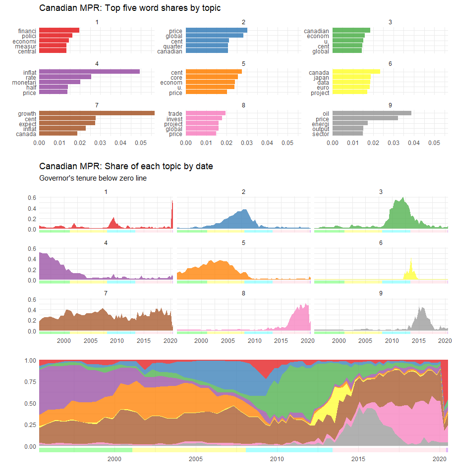

```r
pwords <- lda_word_mpr %>%
  group_by(topic) %>%
  top_n(5, beta) %>%
  ungroup() %>%
  mutate(topic = as_factor(topic), term = reorder_within(term, beta, topic)) %>%
  ggplot(aes(x=term, y=beta, fill=topic)) +
  geom_col(alpha=.85) +
  scale_fill_manual(values=getPalette(k)) +
  scale_y_continuous(expand=c(0,0)) +
  scale_x_reordered() +
  facet_wrap(~ topic, scales="free_y") +
  theme_minimal() +
  theme(legend.position = "none") +
  labs(title="Canadian MPR: Top five word shares by topic", x="", y="") +
  coord_flip()

ptopic <- lda_doc_mpr %>%
  ggplot() +
  geom_area(aes(x=date, y=gamma, group=topic, fill=cc), colour=NA, alpha = .77) +
  theme_minimal() +
  theme(legend.position="none") +
  scale_y_continuous(expand=c(0,0)) +
  scale_x_date(expand=c(0,0)) +
  scale_fill_identity() +
  labs(x="", y="")

ptopic_who <- ptopic +
  geom_rect(data=rect_df, aes(xmin=xl, xmax=xh, ymin=-0.075, ymax=-0.025, fill=cc), alpha=0.33)

ptopic_grid <- ptopic_who +
  facet_wrap( ~ topic, ncol=3) +
  labs(title="Canadian MPR: Share of each topic by date",
       subtitle="Governor's tenure below zero line")

plot_grid(pwords, ptopic_grid, ptopic_who,
          align="v", axis="l", ncol=1, rel_heights=c(1,1.25,0.75))
```

It seems pretty obvious that there is a ‘Carney topic’ (number 3), a ‘crisis topic’ (number 1), and mixtures of different topics in different eras (for example number 8 and 9 for post-recession recovery phases), as well as a ‘base topic’ of some sort (number 7).

I’ll leave it to you to decipher any deeper meaning…

## References

Binette, André, and Dmitri Tchebotarev. 2019. “Canada’s *Monetary Policy Report*: If Text Could Speak, What Would It Say?” Staff Analytical Note 2019-5. Bank of Canada.

Blei, D. M., and J. D. Lafferty. 2007. “A Correlated Topic Model of Science.” *The Annals of Applied Statistics* 1 (1): 17–35.

Blei, D. M., A. Y. Ng, and M. I. Jordan. 2003. “Latent Dirichlet Allocation.” *Journal of Machine Learning Research* 3: 993–1022.

Chang, Jonathan. 2015. *lda: Collapsed Gibbs Sampling Methods for Topic Models*. https://CRAN.R-project.org/package=lda.

Grün, Bettina, and Kurt Hornik. 2011. “Topicmodels: An R Package for Fitting Topic Models.” *Journal of Statistical Software* 40 (13): 1–30.

Roberts, Margaret E., Brandon M. Stewart, and Edoardo M. Airoldic. 2016. “A Model of Text for Experimentation in the Social Sciences.” *Journal of the American Statistical Association* 111 (515): 988–1003.

Roberts, Margaret E., Brandon M. Stewart, and Dustin Tingley. 2019. “stm: An R Package for Structural Topic Models.” *Journal of Statistical Software* 91 (2): 1–40. https://doi.org/10.18637/jss.v091.i02.

[^1]: Potentially I could use bigrams or longer, but here just single words.
[^2]: The tables in the Canadian MPRs used below produce some spurious words, discussed below.
[^3]: This is the same as the POS indicator you may have seen earlier, but a little more subtle.
[^4]: Turns out this doesn’t make much difference but speeds computation a little bit.